# 8_2_ARMA_Homework

# Exercise 2

Consider the United States GDP series (from `global_economy`)

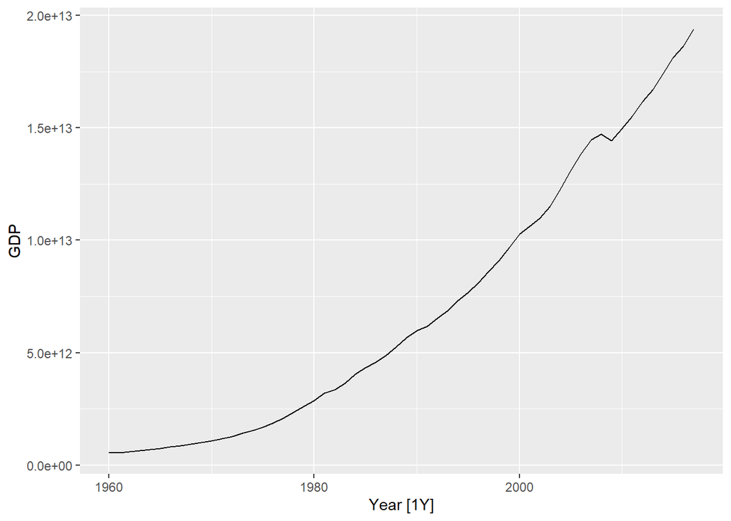

```r
us_economy <- global_economy %>% filter(Code == "USA")
us_economy %>% autoplot(GDP)
```

The data has a non-linear trend. We can either perform multiple order differences to remove the non-linear trend or linearize it prior to differencing. Here we are going to opt for this second option.

1. Perform a box-cox transformation to the data and plot the result

```r
lambda <- us_economy %>%
  features(GDP, features = guerrero) %>%
  pull(lambda_guerrero)
lambda
```

```
[1] 0.2819443
```

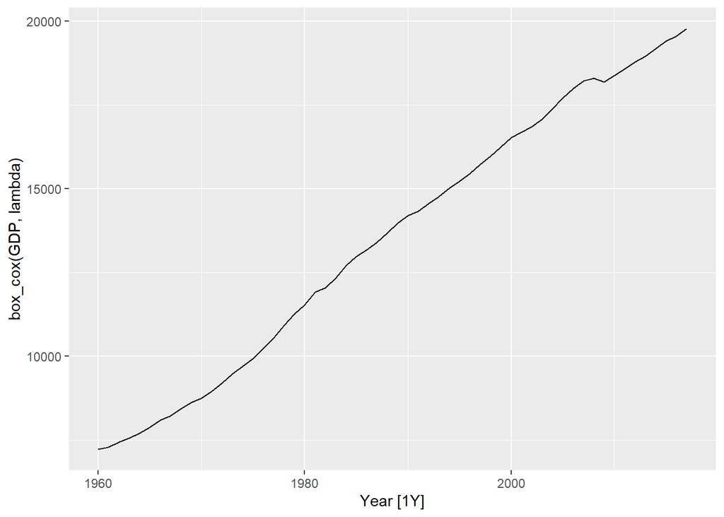

```r
us_economy %>%
  autoplot(box_cox(GDP, lambda))
```

2. Check that applying first order differences to the box-cox transformed data results in a stationary time series.

```r
us_economy <-
  us_economy %>%
    mutate(
       bc_diff = difference(box_cox(GDP, lambda), 1)
          )

us_economy %>%
  features(bc_diff, unitroot_kpss)
```

```
# A tibble: 1 × 3
  Country       kpss_stat kpss_pvalue
  <fct>             <dbl>       <dbl>
1 United States     0.208         0.1
```

3. Model the resulting stationary time series using ARMA. Plot the ACF and PACF to pick up sensible values for p and q. Also fit an auto-ARIMA model using `ARIMA(box_cox(GDP, lambda))` with no further arguments.

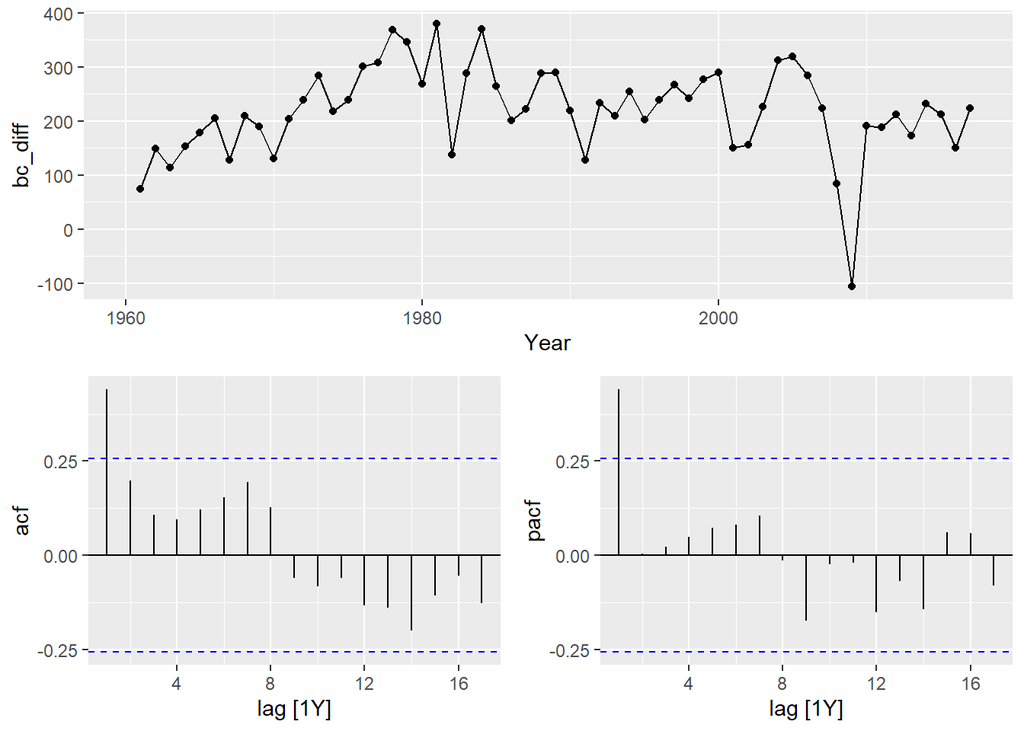

```r
us_economy %>% gg_tsdisplay(bc_diff, plot_type="partial")
```

```r
# Both ACF and PACF seems to cut-off.

# ACF suggest MA1
# PACF suggest AR1

fit <-
  us_economy %>%
    model(
        AR1 = ARIMA(box_cox(GDP, lambda) ~ pdq(1, 0, 0)),
        MA1 = ARIMA(box_cox(GDP, lambda) ~ pdq(0, 0, 1)),
        auto = ARIMA(box_cox(GDP, lambda))
      )
```

```r
IMPORTANT!!
Note that only one of the three models has been fit! The AR1 and MA1 models
lead to models that had coefficients that did not fulfil the root conditions
(complex roots outside the unit circle) and therefore were not fitted.

Only the automatically found model has been fit.
```

4. Select one of the models and analyze the residuals

```r
fit %>% glance()
```

```
# A tibble: 1 × 9
  Country       .model sigma2 log_lik   AIC  AICc   BIC ar_roots  ma_roots
  <fct>         <chr>   <dbl>   <dbl> <dbl> <dbl> <dbl> <list>    <list>
1 United States auto    5479.   -325.  657.  657.  663. <cpl [1]> <cpl [0]>
```

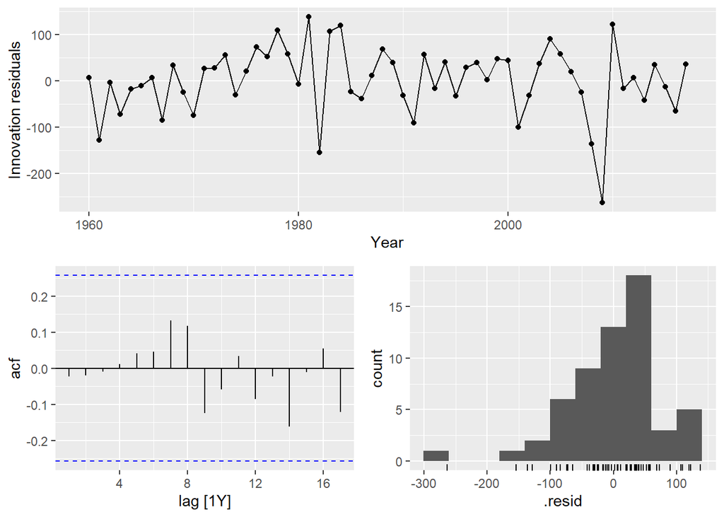

```r
fit %>% select(auto) %>% gg_tsresiduals()
```

```r
Residuals seem uncorrelated, but normality is not fulfilled.

In this scenario we could resort to bootsrapping to generate
prediction intervals.
```